# sizeMat: An R Package to Estimate Size at Sexual Maturity

Josymar Torrejon-Magallanes

2020-05-19

This vignette introduces you to `sizeMat` package and provide a way to estimate **Size at Morphometric and Gonad Maturity**.

### Install package

```r
install.packages("sizeMat")
```

### 1. Size at morphometric maturity

For estimating morphometric maturity use the *crabdata* base. The data set containing allometric measures and other attributes (year, month, sex category) of 223 crabs of the specie *Chionectes tanneri*.

### Load data

```r
data(crabdata)

head(crabdata)
```

```
##   year month carapace_width carapace_length chela_height chela_width
## 1 1974     1            106             107         14.0          22
## 2 1974     1            129             129         27.0          44
## 3 1974     1            119             122         14.6          23
## 4 1974     1            115             118         18.6          29
## 5 1974     1             97              97         11.0          17
## 6 1974     1             94              96         10.0          15
##   sex_category
## 1            m
## 2            m
## 3            m
## 4            m
## 5            m
## 6            m
```

```r
names(crabdata)
```

```
## [1] "year"            "month"           "carapace_width"  "carapace_length"
## [5] "chela_height"    "chela_width"     "sex_category"
```

The estimation of morphometric maturity involves two processes:

First the *data classification*, which is referred to the classification of the individuals in two groups. The second is the *estimation*. This process uses the previous classification to estimate the size at morphometric maturity. The details are given below.

## Classify data (print and plot)

The `classify_mature` function, classify the individuals in two groups (juveniles = 0 and adult = 1). The classification analysis is based on Principal Components Analysis with two allometric variables (x: independent variable, y: dependent variable) in log base, allowing to distinguish two groups that would represent juveniles and adult. The individuals are assigned to each group using a hierarchical classification procedure (hierarchical cluster with agglomeration method: “Ward.D” and the distance measure: “euclidean”). This method is based on establishing a predetermined number of groups (in this case, two) and assigning individuals to one of the groups according to their loads on the two axes of the PCA (Corgos & Freire, 2006).

Using the results of the classification (PCA + cluster), a discriminant analysis (linear or quadratic) is conducted to obtain a discriminating function that permitted any individuals to be classified as a juvenile or an adult on the basis of the X and Y variables.

The `classify_mature` function requires a data.frame (e.g. crabdata) with allometric variables and sex category. The argument `varNames` requires the name of two allometric variables only, and `varSex` requires the name of the variable containing sex information. If the argument `selecSex` is `NULL` all the individuals will be used in the classification analysis. Finally the `method` is focus in the discriminant analysis to be used (“ld”: linear discriminant analysis, “qd”: quadratic discriminant analysis). We recommend begin the analysis with the `method = "ld"`.

The `classify_mature` function returns an object of class “classify”, with the allometric variables “x” (independent) - “y”" (dependent), and classification of maturity (juveniles = 0, adult = 1).

```r
#For all the individuals
classify_data = classify_mature(crabdata, varNames = c("carapace_width", "chela_height"),
varSex = "sex_category", selectSex = NULL, method = "ld")
```

```
## all individuals were used in the analysis
```

```r
#For males only
classify_data_males = classify_mature(crabdata, varNames = c("carapace_width", "chela_height"),
varSex = "sex_category", selectSex = "m", method = "ld")
```

```
## only m-sex were used in the analysis
```

Print the results of the “classify_data” object. It shows the number of juveniles and adults after classification and the linear regression analysis for juveniles and adults.

```r
print(classify_data)
```

```
## Number in juvenile group = 83
##
## Number in adult group = 140
##
## --------------------------------------------------------
## 1) Linear regression for juveniles
##
## Call:
## glm(formula = y ~ x, data = juv)
##
## Deviance Residuals:
##      Min        1Q    Median        3Q       Max
## -2.77010  -0.57399   0.09397   0.56605   1.99008
##
## Coefficients:
##              Estimate Std. Error t value Pr(>|t|)
## (Intercept) -3.794687   0.497056  -7.634 3.93e-11 ***
## x            0.161327   0.004701  34.314  < 2e-16 ***
## ---
## Signif. codes:  0 '***' 0.001 '**' 0.01 '*' 0.05 '.' 0.1 ' ' 1
##
## (Dispersion parameter for gaussian family taken to be 0.7320842)
##
##     Null deviance: 921.306  on 82  degrees of freedom
## Residual deviance:  59.299  on 81  degrees of freedom
## AIC: 213.63
##
## Number of Fisher Scoring iterations: 2
##
## --------------------------------------------------------
## 2) Linear regression for adults
##
## Call:
## glm(formula = y ~ x, data = adt)
##
## Deviance Residuals:
##     Min       1Q   Median       3Q      Max
## -3.3055  -1.0932  -0.0628   1.1178   3.2759
##
## Coefficients:
##               Estimate Std. Error t value Pr(>|t|)
## (Intercept) -11.246726   1.199496  -9.376   <2e-16 ***
## x             0.273837   0.008648  31.663   <2e-16 ***
## ---
## Signif. codes:  0 '***' 0.001 '**' 0.01 '*' 0.05 '.' 0.1 ' ' 1
##
## (Dispersion parameter for gaussian family taken to be 2.265729)
##
##     Null deviance: 2584.24  on 139  degrees of freedom
## Residual deviance:  312.67  on 138  degrees of freedom
## AIC: 515.79
##
## Number of Fisher Scoring iterations: 2
##
## --------------------------------------------------------
## 3) Difference between slopes (ANCOVA)
##               Estimate  Std. Error   t value     Pr(>|t|)
## (Intercept) -3.7946869 0.757105677 -5.012097 1.109526e-06
## x            0.1613275 0.007161179 22.528064 6.035478e-59
## mature      -7.4520389 1.285219562 -5.798261 2.320729e-08
## x:mature     0.1125093 0.010361046 10.858878 2.956242e-22
## [1] "slopes are different"
```

The example shows the arguments that can be used in the plot for “classify_data” object:

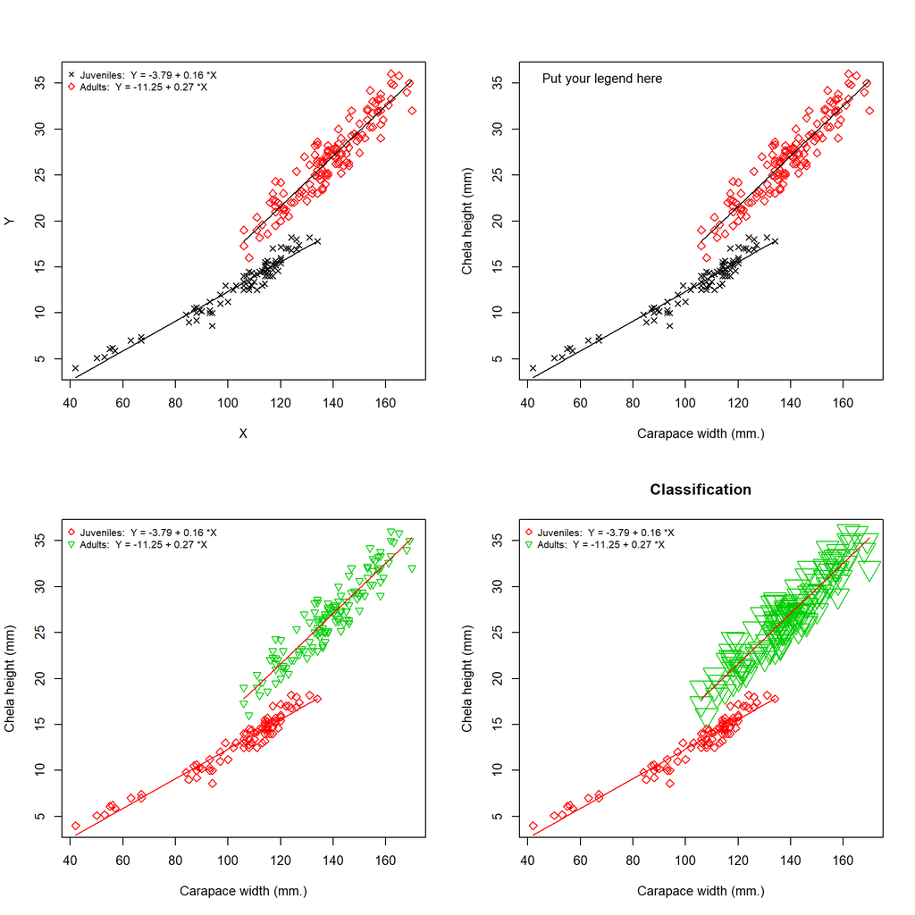

```r
par(mfrow = c(2,2))
plot(classify_data)

plot(classify_data, xlab = "Carapace width (mm.)", ylab = "Chela height (mm)", legendPlot = FALSE)
legend("topleft", "Put your legend here", bty = "n")

plot(classify_data, xlab = "Carapace width (mm.)", ylab = "Chela height (mm)",
     col = c(2, 3), pch = c(5, 6), legendPlot = TRUE)

plot(classify_data, xlab = "Carapace width (mm.)", ylab = "Chela height (mm)",
     col = c(2, 3), pch = c(5, 6), lty_lines = c(1, 2), lwd_lines = c(1, 3),
     cex = c(1, 3), main = "Classification")
```

## Estimate size at morphometric maturity (maturity ogive estimation)

The `morph_mature` function use the logit approach (frequentist or bayesian). The size at 50% maturity ($L_{50}$) was estimated as the length at which a randomly chosen specimen has a 50% chance of being mature (Somerton 1980, Roa et al. 1999).

In the regression analysis, $X$ (e.g: carapace width) is considered the explanatory variable and the classification of maturity $CS$ (juveniles: 0, adults: 1) is considered the response variable (binomial). The variables are fitted to a logit function with the form:

$$P_{CS} = \frac{1}{1+e^{-(\hat{\beta}_{0} + \hat{\beta}_{1}*X)}}$$

where $P_{CS}$ is the probability of an individual of being mature at a determinate $X$ length. $\hat{\beta}_{0}$ (intercept) and $\hat{\beta}_{1}$ (slope) are parameters estimated. The $L_{50}$ is calculated as:

$$L_{50} = -\frac{\hat{\beta}_{0}}{\hat{\beta}_{1}}$$

The `morph_mature` function requires an object of class “classify” with the X, Y (allometric variables) and classification of maturity (juveniles = 0, adults = 1).

The argument `method` requires a character string indicating which regression will be used for the test. If `method = "fq"` the logit regression is based on GLM (frequentist) and if `method = "bayes"` a sample from the posterior distribution of a logit regression model using a random walk Metropolis algorithm is generated (see MCMClogit function).

The argument `niter` requires a number. For the GLM regression (`method = "fq"`), a non-parametric bootstrap method consists in generate B bootstrap samples, by resampling with replacement the original data. Then all statistics for each parameter can be calculated from each bootstrap sample (median and confidence intervals). For the `method = "bayes"`, the argument `niter` is related to the number of Metropolis iterations for the sampler.

The output is an object of class “morphMat”. This object contains a dataframe with the allometric variables X - Y and the classification of maturity. Also the fitted values for the logit regression and confidence intervals (95%). If you print the object, the median of the size at morphometric maturity estimation ($L_{50}$) and parameters are shown.

```r
#Frequentist regression
my_ogive_fq = morph_mature(classify_data, method = "fq", niter = 1000)

print(my_ogive_fq)
```

```
## formula: Y = 1/1+exp-(A + B*X)
```

```
##     Original Bootstrap (Median)
## A   -20.753  -20.8586
## B   0.1748   0.1757
## L50 118.7237 118.6616
## R2  -        0.7111
```

```r
#Bayesian regression
my_ogive_bayes = morph_mature(classify_data, method = "bayes", niter = 1000)

print(my_ogive_bayes)
```

```
## formula: Y = 1/1+exp-(A + B*X)
```

```
##     Bootstrap (Median)
## A             -20.6964
## B               0.1744
## L50           118.4079
## R2              0.7111
```

## Plot maturity ogive

For plotting the maturity ogive, an object of class “morphMat” is required. The function `plot` generates 4 graphics: 1), 2) and 3) are histograms for the A, B parameters and the size at morphometric maturity ($L_{50}$), the last is the maturity ogive.

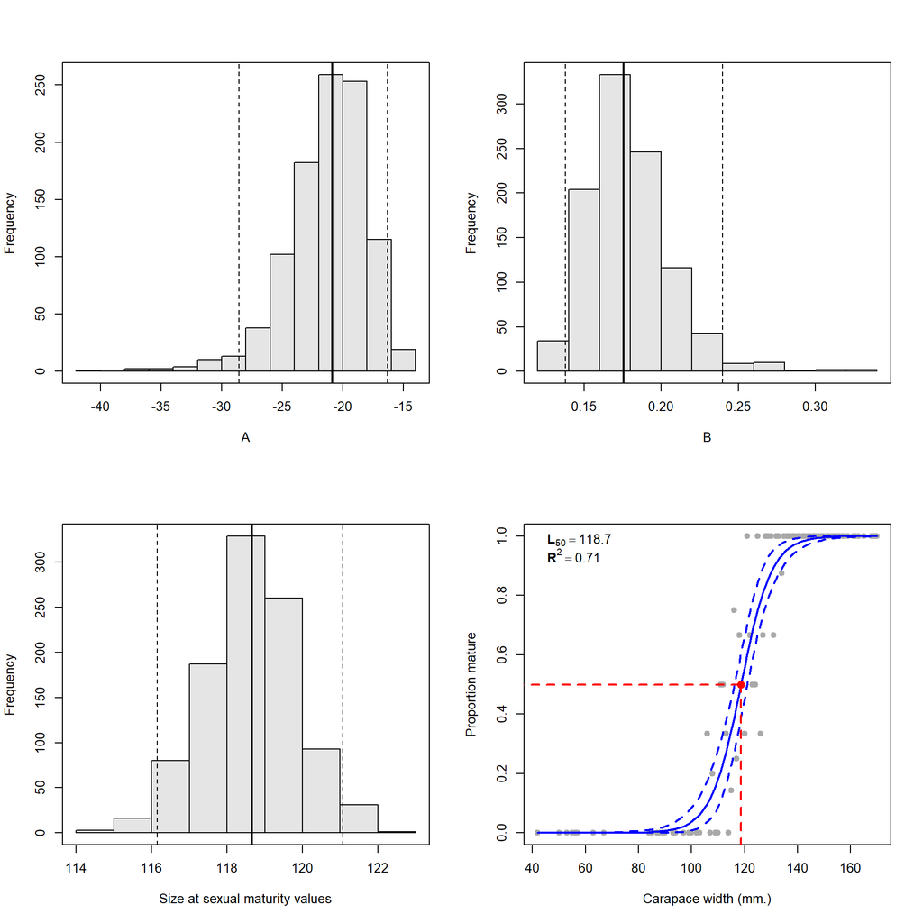

```
## Size at morphometric maturity = 118.7
## Confidence intervals = 116.2 - 121.1
## Rsquare = 0.71
```

```r
par(mfrow = c(2,2))
plot(my_ogive_fq, xlab = "Carapace width (mm.)", ylab = "Proportion mature", col = c("blue", "red"))
```

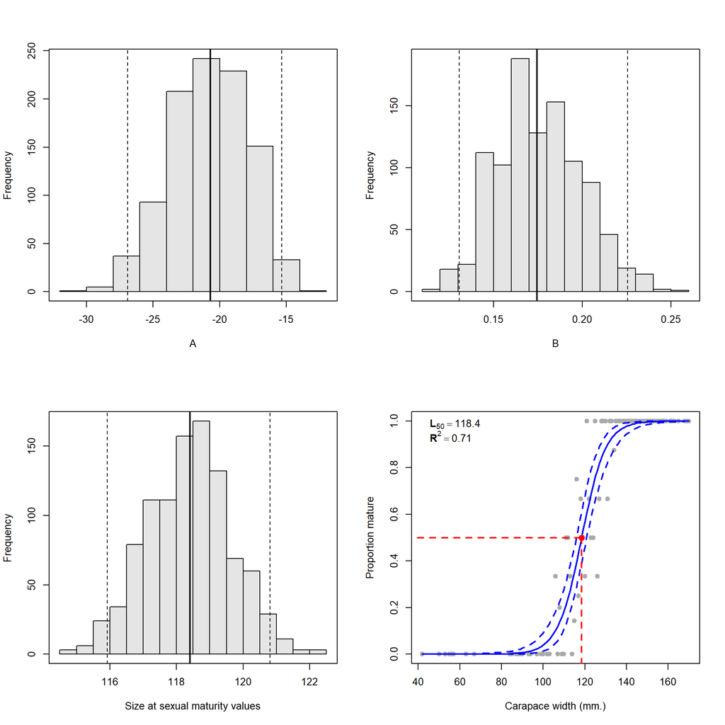

```
## Size at morphometric maturity = 118.4
## Confidence intervals = 115.9 - 120.8
## Rsquare = 0.71
```

```r
par(mfrow = c(2,2))
plot(my_ogive_bayes, xlab = "Carapace width (mm.)", ylab = "Proportion mature", col = c("blue", "red"))
```

If you want the maturity ogive plot only, you have to add the param `onlyOgive = TRUE`. Besides you can modify the axis (size, rotation, etc) and add the legend.

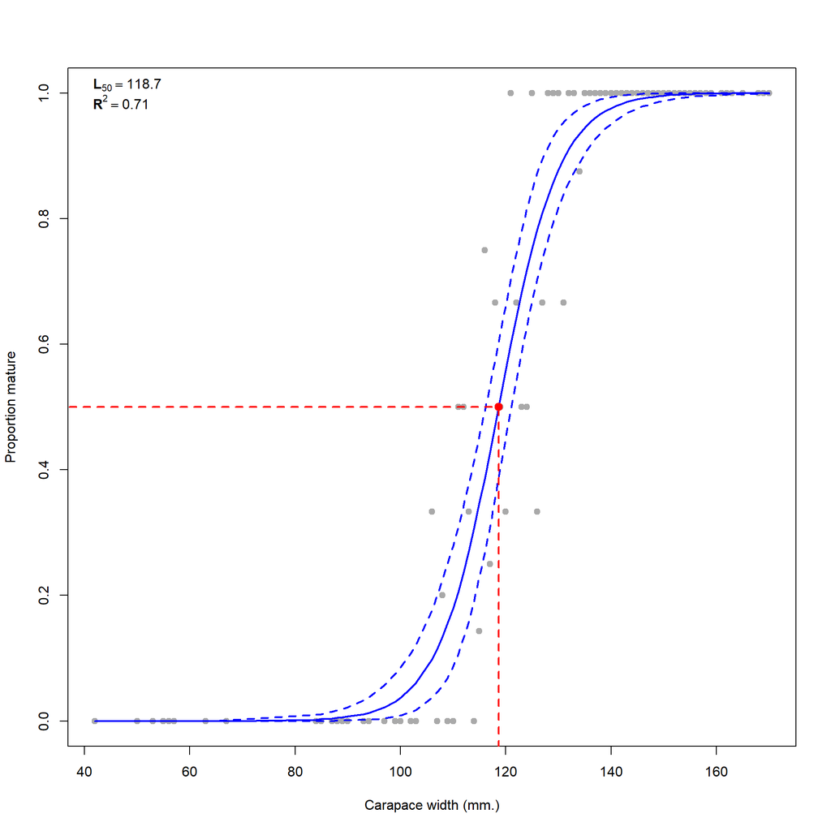

```
## Size at morphometric maturity = 118.7
## Confidence intervals = 116.2 - 121.1
## Rsquare = 0.71
```

```r
plot(my_ogive_fq, xlab = "Carapace width (mm.)", ylab = "Proportion mature", col = c("blue", "red"), onlyOgive = TRUE)
```

This methodology has been used mainly in the estimation of morphological sexual maturity in crabs, but it can be extended to other taxas as Agostinho (2000) reported.

### 2. Size at gonad maturity

For estimating gonadal maturity use the *matFish* database. This database contains two variables:

- `total_length`: Total length in cm.
- `stage_mat`: The gonadal maturation stages: I, II, III, IV, where I is considered immature.

## Load data

```r
data(matFish)

head(matFish)
```

```
##   total_length stage_mat
## 1           12         I
## 2           12         I
## 3           13         I
## 4           14         I
## 5           14         I
## 6           14         I
```

The function to be used to estimate gonadal maturity is `gonad_mature`. This function use the logistic approach.

The `gonad_mature` function requires a data.frame with allometric variables (e.g: total length, fork length, carapace width, etc) and a variable containing the stages of sexual maturity (gonadal maturation stages).

The argument `varNames` requires a character string indicating the name of one allometric and the stage of sexual maturity variable to be used for analysis (e.g `varNames = c("total_length", "stage_mat")`). So the argument `varNames` must contain two character strings only, the first is the allometric variable and the second is the stage of sexual maturity.

The arguments `inmName` and `matName` require a character string indicating the name of the stages of sexual maturity in the data.frame. The argument could contain one character string or could be a vector (e.g `inmName = "I"`, `matName = c("II", "III", "IV")`). The variable *stage_mat* in the *matFish* database, contains the stages of the sexual maturity. In this case, stage I is considered immature and II, III, IV are mature. Then the stages of sexual maturity are transformed in a binomial variable where immature = 0 and mature = 1.

The argument `method` requires a character string indicating which regression will be used for the test. If `method = "fq"` the logit regression is based on GLM (frequentist) and if `method = "bayes"` a sample from the posterior distribution of a logit regression model using a random walk Metropolis algorithm is generated (see MCMClogit function).

The argument `niter` requires a number. For the GLM regression (`method = "fq"`), a non-parametric bootstrap method consists in generate B bootstrap samples, by resampling with replacement the original data. Then all statistics for each parameter can be calculated from each bootstrap sample (median and confidence intervals). For the `method = "bayes"`, the argument `niter` is related to the number of Metropolis iterations for the sampler.

The output is an object of class “gonadMat”. This object contains a dataframe with the allometric variable “X” and stage of sexual maturity (immature = 0, mature = 1). Also the fitted values for the curve logistic regression and confidence intervals (95%). If you print the object, the median of the size at gonad maturity estimation ($L_{50}$) and parameters are shown.

## Estimate size at gonad maturity (maturity ogive estimation)

```r
#Frequentist regression
my_ogive_fq = gonad_mature(matFish, varNames = c("total_length", "stage_mat"), inmName = "I",
                           matName = c("II", "III", "IV" ), method = "fq", niter = 999)

print(my_ogive_fq)
```

```
## formula: Y = 1/1+exp-(A + B*X)
```

```
##     Original Bootstrap (Median)
## A   -8.6047  -8.6407
## B   0.356    0.3576
## L50 24.1694  24.1714
## R2  0.5595   -
```

```r
#Bayesian regression
my_ogive_bayes = gonad_mature(matFish, varNames = c("total_length", "stage_mat"), inmName = "I",
                              matName = c("II", "III", "IV" ), method = "bayes", niter = 999)

print(my_ogive_bayes)
```

```
## formula: Y = 1/1+exp-(A + B*X)
```

```
##     Bootstrap (Median)
## A              -8.4974
## B               0.3522
## L50            24.1295
## R2              0.5595
```

## Plot maturity ogive

For plotting the maturity ogive the object of class “gonadMat”is required. The function `plot` generates 4 graphics: 1), 2) and 3) are histograms for the A, B parameters and the size at gonadal maturity ($L_{50}$), the last is the maturity ogive.

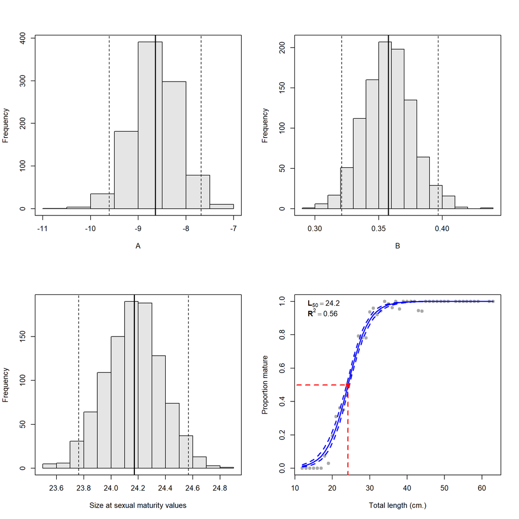

```
## Size at gonad maturity = 24.2
## Confidence intervals = 23.8 - 24.6
## Rsquare = 0.56
```

```r
par(mfrow = c(2,2))
plot(my_ogive_fq, xlab = "Total length (cm.)", ylab = "Proportion mature", col = c("blue", "red"))
```

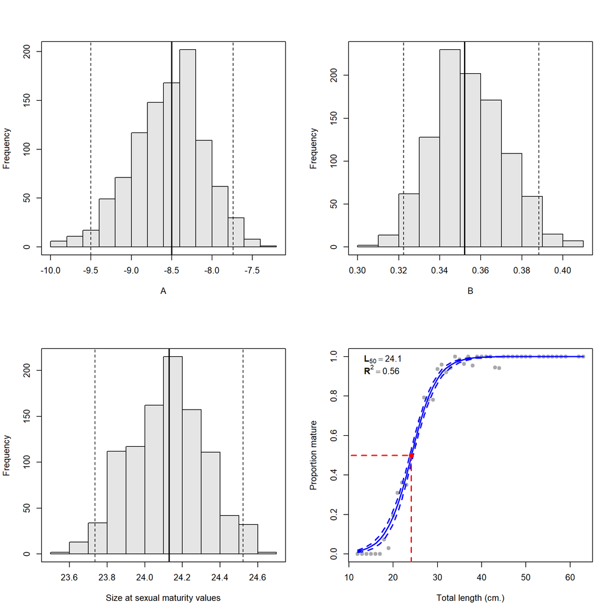

```
## Size at gonad maturity = 24.1
## Confidence intervals = 23.7 - 24.5
## Rsquare = 0.56
```

```r
par(mfrow = c(2,2))
plot(my_ogive_bayes, xlab = "Total length (cm.)", ylab = "Proportion mature", col = c("blue", "red"))
```

If you want the maturity ogive plot only, you have to add the param `onlyOgive = TRUE`. Besides you can modify the axis (size, rotation, etc) and add the legend.

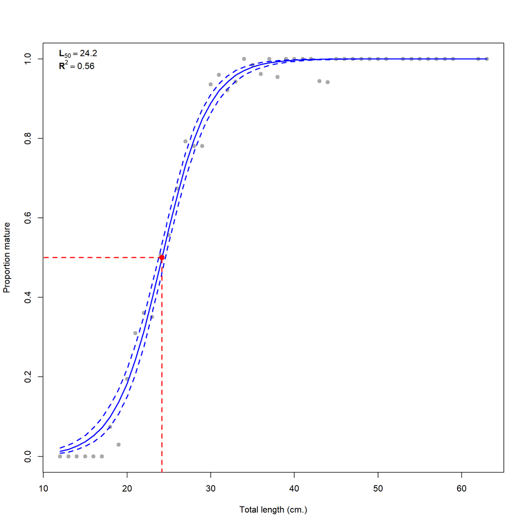

```
## Size at gonad maturity = 24.2
## Confidence intervals = 23.8 - 24.6
## Rsquare = 0.56
```

```r
plot(my_ogive_fq, xlab = "Total length (cm.)", ylab = "Proportion mature", col = c("blue", "red"), onlyOgive = TRUE)
```

## References

Agostinho, C. S. (2000). Use of otoliths to estimate size at sexual maturity in fish. Brazilian Archives of Biology and Technology, 43(4).

Corgos, A. & Freire, J. (2006). Morphometric and gonad maturity in the spider crab Maja brachydactyla: a comparison of methods for estimating size at maturity in species with determinate growth. ICES Journal of Marine Science: Journal du Conseil, 63(5), 851-859.

Roa, R., Ernst, B. & Tapia, F. (1999). Estimation of size at sexual maturity: an evaluation of analytical and resampling procedures. Fishery Bulletin, 97(3), 570-580.

Somerton, D. A. (1980). A computer technique for estimating the size of sexual maturity in crabs. Canadian Journal of Fisheries and Aquatic Sciences, 37(10), 1488-1494.